# Predicting Sales Corporacino Favorita

#### Loading Required Libraries

```r
suppressMessages(library(tidyverse))
suppressMessages(library(TSA))
suppressMessages(library(data.table))
suppressMessages(library(doBy))
suppressMessages(library(formattable))
suppressMessages(library(lubridate))
suppressMessages(library(DT))
suppressMessages(library(timeSeries))

suppressMessages(library(reshape))
suppressMessages(library(stringr))
suppressMessages(library(gridExtra))


suppressMessages(library(wesanderson))
suppressMessages(library(ggplot2))
suppressMessages(library(plotly))
suppressMessages(library(corrplot))
suppressMessages(library(RColorBrewer))
suppressMessages(library(zoo))

suppressMessages(library(forecast))
suppressMessages(library(tseries))

set.seed(42)
```

#### Loading Datasets

```r
train=read.csv("train.csv")
train$date <- as.Date(train$date, "%Y-%m-%d")
sprintf("The training set has %d rows and %d columns", nrow(train), ncol(train) )
str(train)

test <- read.csv("test.csv")
test$date <- as.Date(test $date, "%Y-%m-%d")
sprintf("The test set has %d rows and %d columns", nrow(test ), ncol(test ) )
str(test)
```

'The training set has 913000 rows and 4 columns'

```
'data.frame':	913000 obs. of  4 variables:
 $ date : Date, format: "2013-01-01" "2013-01-02" ...
 $ store: int  1 1 1 1 1 1 1 1 1 1 ...
 $ item : int  1 1 1 1 1 1 1 1 1 1 ...
 $ sales: int  13 11 14 13 10 12 10 9 12 9 ...
```

'The test set has 45000 rows and 4 columns'

```
'data.frame':	45000 obs. of  4 variables:
 $ id   : int  0 1 2 3 4 5 6 7 8 9 ...
 $ date : Date, format: "2018-01-01" "2018-01-02" ...
 $ store: int  1 1 1 1 1 1 1 1 1 1 ...
 $ item : int  1 1 1 1 1 1 1 1 1 1 ...
```

### Descriptive Statistics and EDA

```r
head(train)
```

A data.frame: 6 × 4

| date <date> | store <int> | item <int> | sales <int> |
| --- | --- | --- | --- |
| 2013-01-01 | 1 | 1 | 13 |
| 2013-01-02 | 1 | 1 | 11 |
| 2013-01-03 | 1 | 1 | 14 |
| 2013-01-04 | 1 | 1 | 13 |
| 2013-01-05 | 1 | 1 | 10 |
| 2013-01-06 | 1 | 1 | 12 |

Adding two columns *year* and *month* from *date*

```r
train$Year=year(train$date)
train$Month=as.yearmon(train$date)
```

```r
head(train)
```

A data.frame: 6 × 6

| date <date> | store <int> | item <int> | sales <int> | Year <dbl> | Month <yearmon> |
| --- | --- | --- | --- | --- | --- |
| 2013-01-01 | 1 | 1 | 13 | 2013 | Jan 2013 |
| 2013-01-02 | 1 | 1 | 11 | 2013 | Jan 2013 |
| 2013-01-03 | 1 | 1 | 14 | 2013 | Jan 2013 |
| 2013-01-04 | 1 | 1 | 13 | 2013 | Jan 2013 |
| 2013-01-05 | 1 | 1 | 10 | 2013 | Jan 2013 |
| 2013-01-06 | 1 | 1 | 12 | 2013 | Jan 2013 |

```r
print("the summary of train sales is:")
summary(train$sales)
```

```
[1] "the summary of train sales is:"
```

```
   Min. 1st Qu.  Median    Mean 3rd Qu.    Max.
   0.00   30.00   47.00   52.25   70.00  231.00
```

#### Unit Sales Histogram

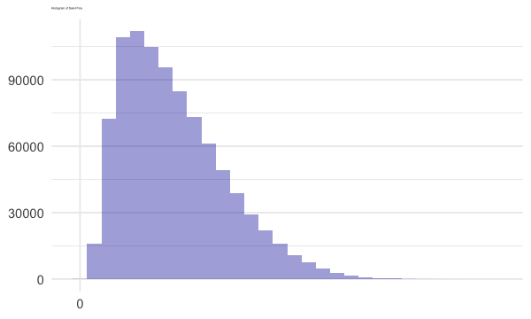

```r
options(repr.plot.width=5, repr.plot.height=3)

gbp1<-wes_palette("IsleofDogs1")[1]

ggplot(train, aes(x=sales))+
  geom_histogram(fill="#1122aa", alpha=.4) + labs(x=NULL, y=NULL, title = "Histogram of Sale Price")+
   scale_x_continuous(breaks= seq(0,600000, by=100000)) + theme_minimal() + theme(plot.title=element_text(vjust=3, size=2) )
```

#### Sales Growth By Date

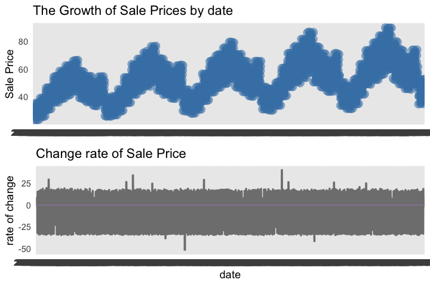

```r
options(repr.plot.width=6, repr.plot.height=4)

sales_by_date <- aggregate(sales ~date, train, mean)

sl1 <-ggplot(sales_by_date, aes(x=as.factor(date), y=sales)) + geom_line(color='steelblue', aes(group=1), size=1.5) +
    geom_point(colour='steelblue', size = 3.5, alpha=0.5) +
    labs(title="The Growth of Sale Prices by date", x=NULL, y="Sale Price") + theme(  aspect.ratio = 0.2 ) + theme_minimal()

sales_by_date$change = c(0, 100*diff(sales_by_date$sales)/sales_by_date[-nrow(sales_by_date),]$sales)

sl2 <-ggplot(sales_by_date, aes(x=as.factor(date), y=change))+
  geom_line(color= "gray50", aes(group=1), size=1)+
  labs(title="Change rate of Sale Price", x="date", y="rate of change")+
  geom_hline(yintercept = 0, color = gbp1 )+
  theme(aspect.ratio = 0.2)+ theme_minimal()

grid.arrange(sl1,sl2)
```

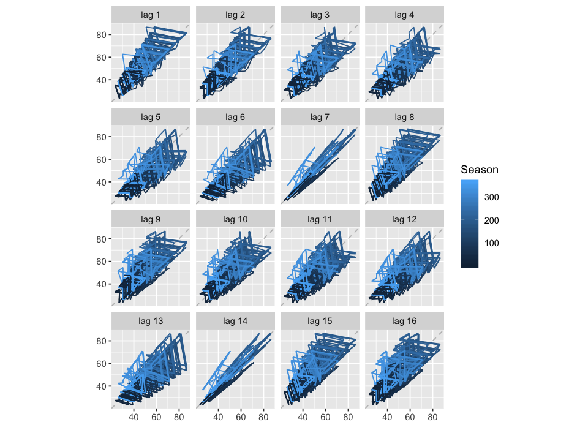

```r
options(repr.plot.width=8, repr.plot.height=6)

sales_ts<-ts(sales_by_date$sales,frequency = 365,start = c(2013,01), end = c(2017,12))
gglagplot(sales_ts)
```

#### Sales Growth by Month

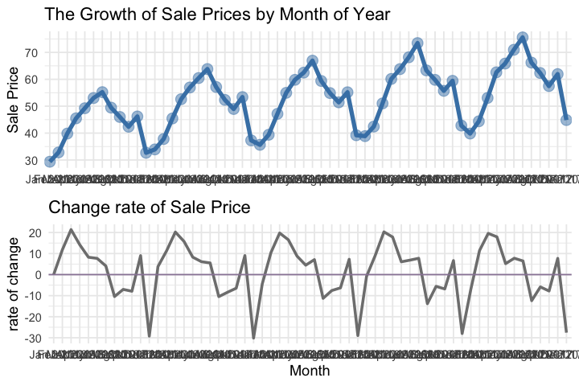

```r
options(repr.plot.width=6, repr.plot.height=4)

sales_by_month <- aggregate(sales ~Month, train, mean)

sl1 <-ggplot(sales_by_month, aes(x=as.factor(Month), y=sales)) + geom_line(color='steelblue', aes(group=1), size=1.5)+
  geom_point(colour='steelblue', size = 3.5, alpha=0.5)+
  labs(title="The Growth of Sale Prices by Month of Year", x=NULL, y="Sale Price")+
  theme( plot.title=element_text(vjust=3, size=15) ) + theme_minimal()

sales_by_month$change = c(0, 100*diff(sales_by_month$sales)/sales_by_month[-nrow(sales_by_month),]$sales)

sl2 <-ggplot(sales_by_month, aes(x=as.factor(Month), y=change)) + geom_line(color= "gray50", aes(group=1), size=1)+
  labs(title="Change rate of Sale Price", x="Month", y="rate of change") + geom_hline(yintercept = 0, color = gbp1 )+
  theme(plot.title=element_text(size=15))+ theme_minimal()

grid.arrange(sl1,sl2)
```

- While the rate of change in unit sales remain constant at a daily level, but we can see it fluctuates when observed on a monthly basis. Hence we can say seasonality exists.
- The sales price shows an increasing trend.

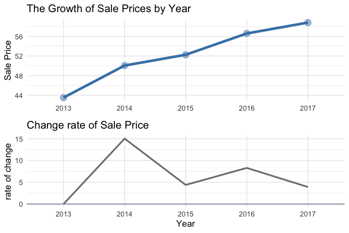

```r
options(repr.plot.width=6, repr.plot.height=4)

sales_by_year <- aggregate(sales ~Year, train, mean)

sl1 <-ggplot(sales_by_year, aes(x=as.factor(Year), y=sales)) + geom_line(color='steelblue', aes(group=1), size=1.5)+
  geom_point(colour='steelblue', size = 3.5, alpha=0.5)+
  labs(title="The Growth of Sale Prices by Year", x=NULL, y="Sale Price")+
  theme( plot.title=element_text(vjust=3, size=15) ) + theme_minimal()

sales_by_year$change = c(0, 100*diff(sales_by_year$sales)/sales_by_year[-nrow(sales_by_year),]$sales)

sl2 <-ggplot(sales_by_year, aes(x=as.factor(Year), y=change)) + geom_line(color= "gray50", aes(group=1), size=1)+
  labs(title="Change rate of Sale Price", x="Year", y="rate of change") + geom_hline(yintercept = 0, color = gbp1 )+
  theme(plot.title=element_text(size=15))+ theme_minimal()

grid.arrange(sl1,sl2)
```

- Growth of Sales price increases at yearly level.
- In the rate of change of sales price we can observe that it increases from 2013-14, with a big dip in 2015.
- That same pattern is observed from 2015-17.

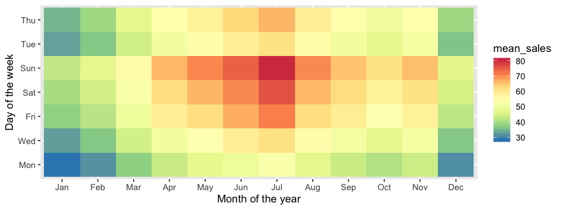

```r
options(repr.plot.width=8, repr.plot.height=3)

p1 <- train %>%

  mutate(wday = wday(date, label = TRUE),

         month = month(date, label = TRUE)) %>%

  mutate(wday = fct_relevel(wday, c("Mon", "Tues", "Wed", "Thurs", "Fri", "Sat", "Sun"))) %>%

  group_by(wday, month) %>%

  summarise(mean_sales = mean(sales)) %>%

  ggplot(aes(month, wday, fill = mean_sales)) +

  geom_tile() +

  labs(x = "Month of the year", y = "Day of the week") +

  scale_fill_distiller(palette = "Spectral")

plot(p1)
```

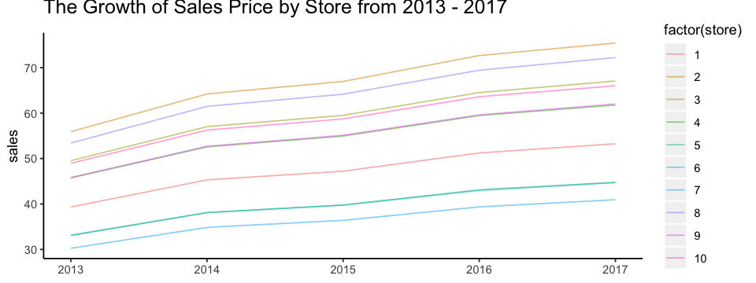

```r
Year_state<-aggregate(sales ~store+Year, train,mean)
pal<-rep(brewer.pal(10, "PuBuGn"),5)

ggplot(Year_state, aes(group = factor(store) ))+
  geom_line(aes(x=Year,y=sales,color=factor(store)), alpha=0.5, show.legend=TRUE)+
  labs(title="The Growth of Sales Price by Store from 2013 - 2017", x=NULL
  )+
  theme(panel.background=element_rect(fill = "White"), plot.title=element_text(vjust=3, size=15),
        panel.grid.major=element_blank(), axis.line = element_line(colour = "black"))
```

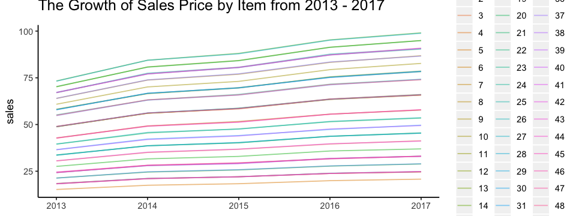

```r
Year_state<-aggregate(sales ~item+Year, train,mean)
pal<-rep(brewer.pal(10, "PuBuGn"),5)

ggplot(Year_state, aes(y=sales, x=Year, group = factor(item) ))+
  geom_line(aes(x=Year,y=sales,color=factor(item)), alpha=0.5, show.legend=TRUE)+
  labs(title="The Growth of Sales Price by Item from 2013 - 2017", x=NULL
  )+
  theme(panel.background=element_rect(fill = "White"),
        plot.title=element_text(vjust=3, size=15),
        panel.grid.major=element_blank(), axis.line = element_line(colour = "black"))
```

Function utility for plotting overlay functions of errors

```r
plotErrors <- function(ferrors)
{
  calcbinsize <- IQR(ferrors,na.rm=TRUE)/4
  calcsd   <- sd(ferrors,na.rm=TRUE)
  calcmin  <- min(ferrors,na.rm=TRUE) - calcsd*5
  calcmax  <- max(ferrors,na.rm=TRUE) + calcsd*3
  calcnorm <- rnorm(10000, mean=0, sd=calcsd)
  calcmin2 <- min(calcnorm)
  calcmax2 <- max(calcnorm)
  if (calcmin2 < calcmin) { calcmin <- calcmin2 }
  if (calcmax2 > calcmax) { calcmax <- calcmax2 }
  calcbins <- seq(calcmin, calcmax, calcbinsize)
  hist(ferrors, col="orange", freq=FALSE, breaks=calcbins)
  calchist <- hist(calcnorm, plot=FALSE, breaks=calcbins)
  points(calchist$mids, calchist$density, type="l", col="red", lwd=2)
}
```

### We have total 50 items and 10 stoers. we have to forecast sale of each item in a store seprately. Lets first explore a single product in a store randomly. Lets analyze on 4th item of 5th store.

Lets create a subset of the data for the same

```r
item_id_4_5 = subset(train, store == 5 & item == 4 )
### creating time series object
item_id_4_5_ts<-ts(item_id_1_1$sales,frequency = 12,start = c(2013,01), end = c(2017,12))
```

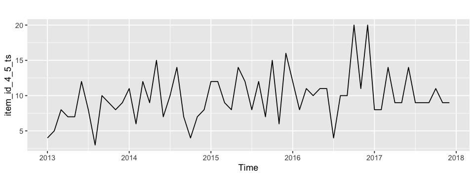

```r
options(repr.plot.width=8, repr.plot.height=3)
autoplot(item_id_4_5_ts)
```

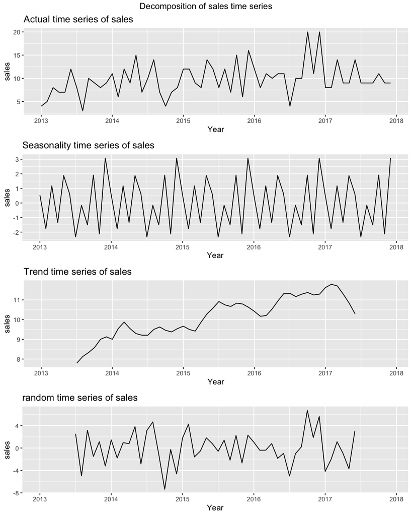

```r
options(repr.plot.width=8, repr.plot.height=10)
sales_ts_decompose<-decompose(item_id_4_5_ts, type = c("additive"))

actual<-autoplot(sales_ts_decompose$x)+xlab("Year")+ylab("sales")+ggtitle("Actual time series of sales")
seas<-autoplot(sales_ts_decompose$seasonal)+xlab("Year")+ylab("sales")+ggtitle("Seasonality time series of sales")
tren<-autoplot(sales_ts_decompose$trend)+xlab("Year")+ylab("sales")+ggtitle("Trend time series of sales")
rand<-autoplot(sales_ts_decompose$random)+xlab("Year")+ylab("sales")+ggtitle("random time series of sales")
grid.arrange(actual,seas,tren,rand,ncol=1,top="Decomposition of sales time series")
```

Time Series decomposition plot

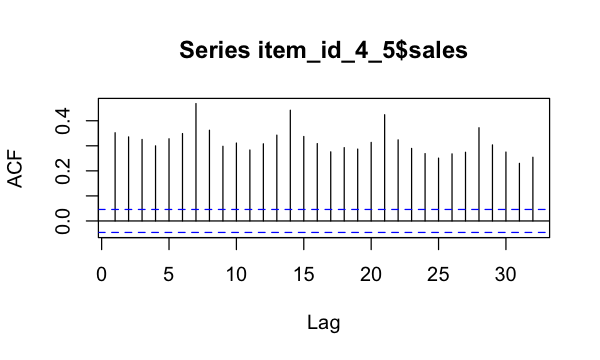

```r
options(repr.plot.width=5, repr.plot.height=3)
acf(item_id_4_5$sales)
```

Autocorrelation of the sales are significant than given confidence interval

```r
adf.test(item_id_4_5$sales)
```

```
	Augmented Dickey-Fuller Test

data:  item_id_4_5$sales
Dickey-Fuller = -4.9506, Lag order = 12, p-value = 0.01
alternative hypothesis: stationary
```

In ACF plot some of the sales are significant than given confidence interval but adf test is stating the stationarity. Hence there must be a trend stationary. We have seen similar in our decomposition plot. Lets fit some regression model to capture this trend.

### We are using stack ensembling of Time series Regression and ARIMA. That is we will fit ARIMA model on residual of the Regression Model

### Our final forecast is summation of Regression forecast and Arima Forecast i.e.

### Final Forecast = Regression Forecast + Arima Forecast

```r
item_1_1_ts_lm = tslm(item_id_1_1_ts ~ trend + season)
item_1_1_ts_forecast = forecast(item_1_1_ts_lm,h=90)
summary(item_1_1_ts_lm)
```

```
Call:
tslm(formula = item_id_1_1_ts ~ trend + season)

Residuals:
   Min     1Q Median     3Q    Max
 -7.10  -1.65  -0.50   1.95   7.50

Coefficients:
            Estimate Std. Error t value Pr(>|t|)
(Intercept)  7.94167    1.57042   5.057 6.93e-06 ***
trend        0.05833    0.02458   2.373   0.0218 *
season2     -1.65833    2.04392  -0.811   0.4213
season3      1.28333    2.04437   0.628   0.5332
season4     -0.97500    2.04511  -0.477   0.6358
season5      1.56667    2.04614   0.766   0.4477
season6      1.50833    2.04747   0.737   0.4650
season7     -1.95000    2.04909  -0.952   0.3461
season8     -0.20833    2.05101  -0.102   0.9195
season9     -1.26667    2.05322  -0.617   0.5403
season10     1.87500    2.05572   0.912   0.3664
season11    -1.78333    2.05851  -0.866   0.3907
season12     2.35833    2.06159   1.144   0.2584
---
Signif. codes:  0 ‘***’ 0.001 ‘**’ 0.01 ‘*’ 0.05 ‘.’ 0.1 ‘ ’ 1

Residual standard error: 3.231 on 47 degrees of freedom
Multiple R-squared:  0.295,	Adjusted R-squared:  0.115
F-statistic: 1.639 on 12 and 47 DF,  p-value: 0.1131
```

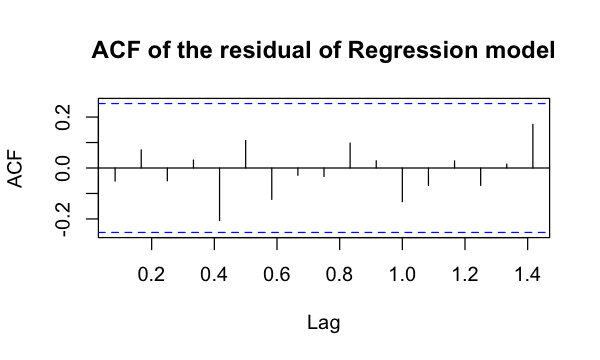

```r
CalcResidual = item_1_1_ts_forecast$residual
acf(CalcResidual, main = 'ACF of the residual of Regression model')
```

The lack of autocorrelation shows that our forecast are good

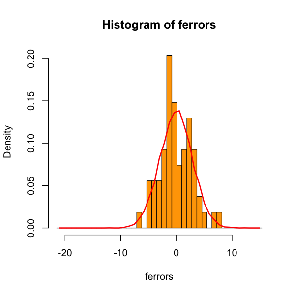

```r
options(repr.plot.width=5, repr.plot.height=5)
plotErrors(CalcResidual)
```

From the above graph we can see the normality of the residual, lets check QQ plot

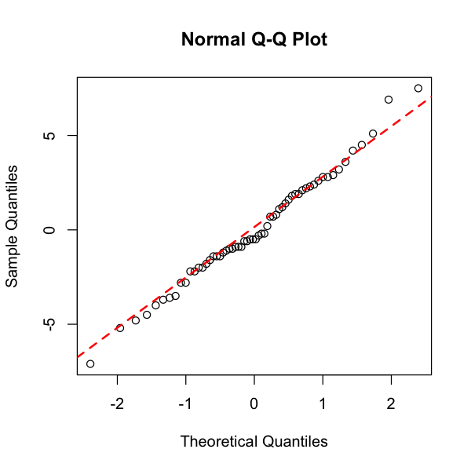

```r
options(repr.plot.width=5, repr.plot.height=5)
qqnorm(CalcResidual)
qqline(CalcResidual, col = 2,lwd=2,lty=2)
```

QQPlot shows the normality of residual, lets run Shapiro-Wilk test

```r
shapiro.test(CalcResidual)
```

```
	Shapiro-Wilk normality test

data:  CalcResidual
W = 0.98933, p-value = 0.8797
```

Large p value means we cannot rejcect null hypothesis. We cannot reject the null hypothesis that residual is normally distributed.

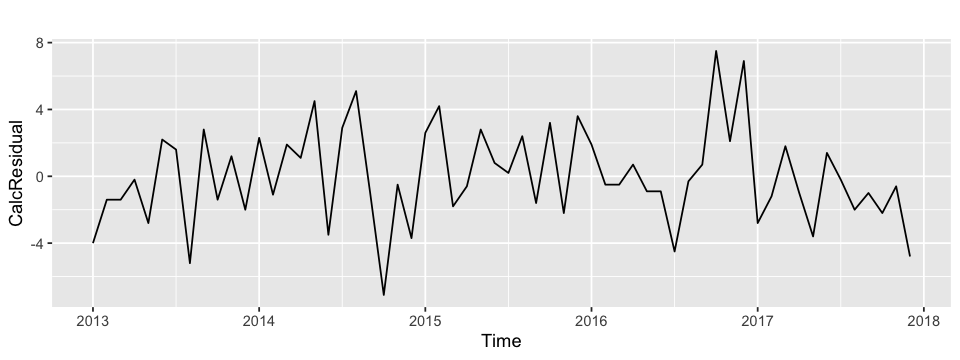

```r
### Residual plot
options(repr.plot.width=8, repr.plot.height=3)
autoplot(CalcResidual)
```

From above residual plot we can see there is no pattern in residuals they are random around mean 0.

Now, lets fit ARIMA on residual of Time Series Regression method.

```r
ArimaResidualFit = auto.arima(item_1_1_ts_lm$residual)
ArimaResidualFitforecast = forecast(ArimaResidualFit,h=90)
ArimaResidualFit
```

```
Series: item_1_1_ts_lm$residual
ARIMA(0,0,0) with zero mean

sigma^2 estimated as 8.18:  log likelihood=-148.19
AIC=298.37   AICc=298.44   BIC=300.47
```

#### tada, forecast errors of our Regression model is white noise. Hence ARIMA model is of order (0, 0, 0). ARIMA(0,0,0) is white noise. Regression model captured all the deterministic component

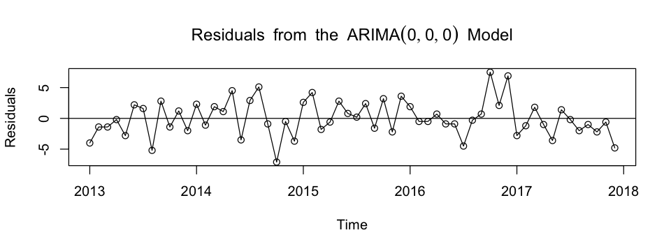

```r
options(repr.plot.width=8, repr.plot.height=3)
plot(window(ArimaResidualFit$residuals,start=c(2003,01), end=c(2017,12)),ylab='Residuals', type='o',
main=expression(Residuals~~from~~the~~ARIMA(list(0,0,0))~~Model))
abline(h=0)
```

From the residual we can see there is no such outlier and does not suggest any irregularties.All of the residual are random no paatern.

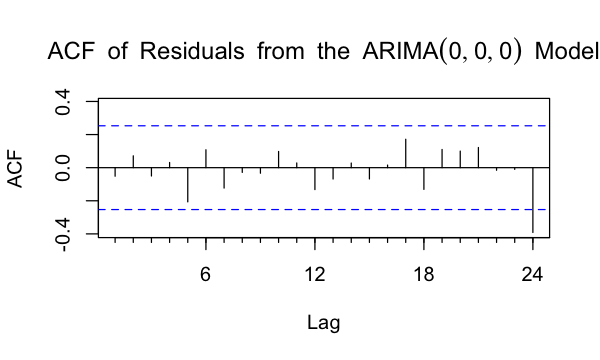

```r
options(repr.plot.width=5, repr.plot.height=3)
Acf(window(ArimaResidualFit$residuals,start=c(2003,01),end=c(2017,12)),
main=expression(ACF~~of~~Residuals~~from~~the~~ARIMA(list(0,0,0))~~Model))
```

The only statistically significant correlation is at lag 24

```r
Box.test(ArimaResidualFit$residuals, lag = 24, type = 'Ljung', fitdf = 2)
```

```
	Box-Ljung test

data:  ArimaResidualFit$residuals
X-squared = 31.948, df = 22, p-value = 0.07829
```

The Box-Ljung test for this model fails to rejct the hypothesis of residual whiteness(alpha = 0.05), Hence we got more indication that the model has captured the dependence in the time series

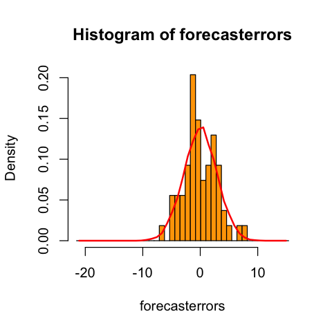

```r
options(repr.plot.width=4, repr.plot.height=4)
plotForecastErrors(ArimaResidualFit$residuals)
```

Shape of the above histogram is bell curver but not exactly normal, lets check QQ plot

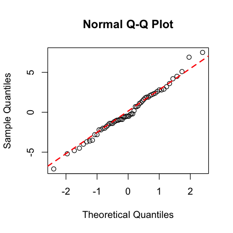

```r
qqnorm(ArimaResidualFit$residuals)
qqline(ArimaResidualFit$residuals, col = 2,lwd=2,lty=2)
```

## Lets genralize this modeling technique on every item of every store

```r
item <- list()
store <- list()

for(i in 1:50) { # 50 items
    for(j in 1:10){ # 10 stores

        # create searate dataframes
        assign(paste("train",j,i,sep="."),subset(train, store == j & item == i )) -> data

        assign(paste("timeseries_data",j,i,sep="."), ts(data["sales"], start = c(2013,01), end = c(2017,12),frequency = 12)) -> timeseries_data

        # Regression forecast

        assign(paste("linear_model",j,i,sep="."),tslm(timeseries_data ~ trend + season) ) -> linear_model
        assign(paste("linear_model_forecast",j,i,sep="."),forecast(linear_model,h=90) ) -> linear_model_forecast

       # ARIMA forecast on the linear_model_residuals

        assign(paste("linear_model_residuals",j,i,sep="."),auto.arima(linear_model$residual)) -> linear_model_residuals
        assign(paste("linear_model_residuals_forecast",j,i,sep="."), forecast(linear_model_residuals,h=90)) -> linear_model_residuals_forecast

       # Final Forecast = Regression Forecast + Residual Forecast

        assign(paste("y",j,i,sep="."), data.frame(linear_model_forecast)$Point.Forecast ) -> y
        assign(paste("x",j,i,sep="."), data.frame(linear_model_residuals_forecast)$Point.Forecast ) -> x
        assign(paste("final_forecast_sales",j,i,sep="."), data.frame(round(x+y,0)) ) -> final_forecast_sales


        item[[j]] <- final_forecast_sales   # add it to your list
}

        assign(paste("item",i,sep="."),do.call(rbind,item) ) -> ii

        store[[i]] <- ii # add it to your list

}

assign(paste("demand.sales"),do.call(rbind,store))

# submissiond

names(demand.sales) <- "sales"

test_timeseries_stackensemble <- cbind(test,demand.sales)
test_timeseries_stackensemble <- test_timeseries_stackensemble[,c("id","sales")]

write.csv(test_timeseries_stackensemble, 'test_timeseries_stackensemble_answer.csv')
head(test_timeseries_stackensemble)
```

A data.frame: 6 × 2

| id <int> | sales <dbl> |
| --- | --- |
| 0 | 12 |
| 1 | 13 |
| 2 | 11 |
| 3 | 12 |
| 4 | 11 |
| 5 | 11 |

```r
summary(linear_model.10.4)
```

```
Call:
tslm(formula = timeseries_data ~ trend + season)

Residuals:
   Min     1Q Median     3Q    Max
-8.800 -2.888 -0.300  2.025 10.075

Coefficients:
            Estimate Std. Error t value Pr(>|t|)
(Intercept) 11.23958    2.35159   4.780 1.77e-05 ***
trend        0.11042    0.03681   3.000  0.00431 **
season2     -2.11042    3.06064  -0.690  0.49388
season3     -1.82083    3.06131  -0.595  0.55484
season4      1.06875    3.06241   0.349  0.72866
season5      0.35833    3.06396   0.117  0.90740
season6     -0.75208    3.06595  -0.245  0.80729
season7     -1.46250    3.06838  -0.477  0.63583
season8      0.62708    3.07125   0.204  0.83910
season9     -4.28333    3.07456  -1.393  0.17013
season10    -0.39375    3.07830  -0.128  0.89876
season11    -2.10417    3.08248  -0.683  0.49820
season12     1.98542    3.08709   0.643  0.52326
---
Signif. codes:  0 ‘***’ 0.001 ‘**’ 0.01 ‘*’ 0.05 ‘.’ 0.1 ‘ ’ 1

Residual standard error: 4.839 on 47 degrees of freedom
Multiple R-squared:  0.2589,	Adjusted R-squared:  0.06965
F-statistic: 1.368 on 12 and 47 DF,  p-value: 0.2149
```

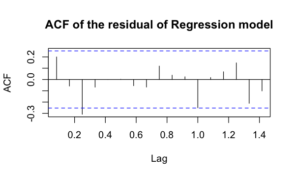

```r
options(repr.plot.width=5, repr.plot.height=3)
CalcResidual = linear_model.10.4$residual
acf(CalcResidual, main = 'ACF of the residual of Regression model')
```

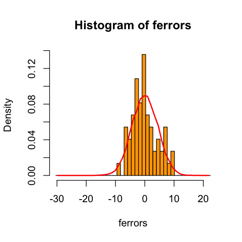

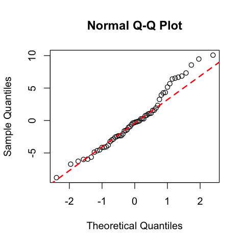

```r
options(repr.plot.width=4, repr.plot.height=4)
plotErrors(CalcResidual)
qqnorm(CalcResidual)
qqline(CalcResidual, col = 2,lwd=2,lty=2)
```

Normality of the Residual of the linear model is not striclty followed in above graph

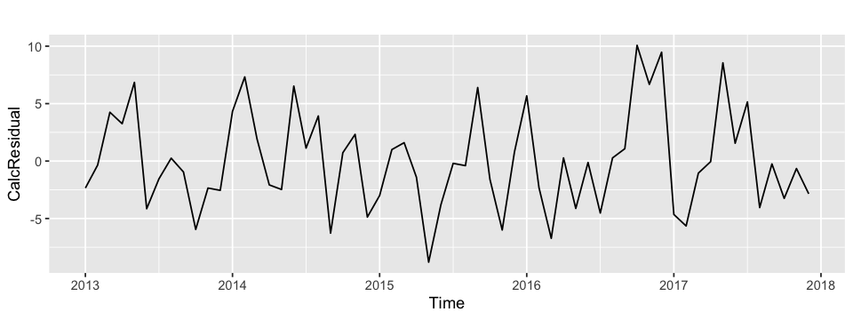

```r
### Residual plot
options(repr.plot.width=8, repr.plot.height=3)
autoplot(CalcResidual)
```

Lets look at the arima model on the residual.

```r
linear_model_residuals.10.4
```

```
Series: linear_model$residual
ARIMA(0,0,1)(1,0,0)[12] with zero mean

Coefficients:
         ma1     sar1
      0.2423  -0.3272
s.e.  0.1153   0.1308

sigma^2 estimated as 16.15:  log likelihood=-168.29
AIC=342.59   AICc=343.01   BIC=348.87
```

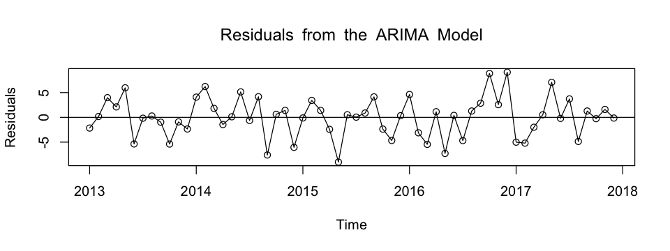

```r
options(repr.plot.width=8, repr.plot.height=3)
plot(window(linear_model_residuals.10.4$residuals,start=c(2003,01), end=c(2017,12)),ylab='Residuals', type='o',
main=expression(Residuals~~from~~the~~ARIMA~~Model))
abline(h=0)
```

From the residual we can see there is no such outlier and does not suggest any irregularties. All of the residual are random no paatern.

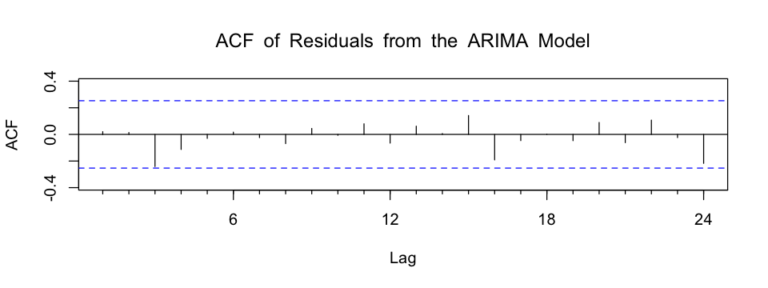

```r
options(repr.plot.width=8, repr.plot.height=3)
Acf(window(linear_model_residuals.10.4$residuals,start=c(2003,01),end=c(2017,12)),
main=expression(ACF~~of~~Residuals~~from~~the~~ARIMA~~Model))
```

```r
Box.test(linear_model_residuals.10.4$residuals, lag = 4, type = 'Ljung', fitdf = 2)
```

```
	Box-Ljung test

data:  linear_model_residuals.10.4$residuals
X-squared = 4.6925, df = 2, p-value = 0.09573
```

The Box-Ljung test for this model fails to rejct the hypothesis of residual whiteness(alpha = 0.05), Hence we got more indication that the model has captured the dependence in the time series

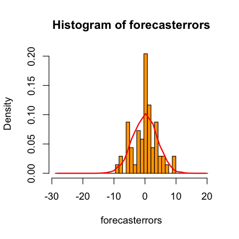

```r
options(repr.plot.width=4, repr.plot.height=4)
plotForecastErrors(linear_model_residuals.10.4$residuals)
```

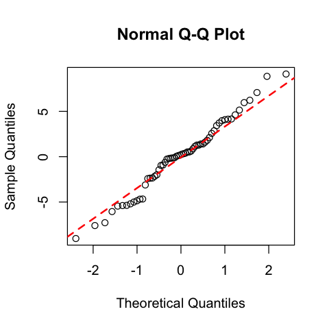

```r
qqnorm(linear_model_residuals.10.4$residuals)
qqline(linear_model_residuals.10.4$residuals, col = 2,lwd=2,lty=2)
```

Some of the points are outliers and normality is not striclty followed